# TransitivityDataAnalysis

Zeynep Enkavi

January 19, 2015

```r
load("~/Dropbox/CDS/Transitivity/TransitivityOutputs/TransitivityDataOrgWorkspace021115.RData")

library(ggplot2)
library(lme4)
library(lmerTest)
library(plyr)
library(dplyr)
```

## Group differences in intransitivies

### Old approach: Looking at the two tasks separately (control vs test task)

```r
#Summary statistics for both tasks
#Raw numbers of intransitivities
aggregate(CleanIntr ~ Group+Task, data=both.Intransitive, mean)
```

```
##   Group    Task CleanIntr
## 1     C  choice    30.900
## 2   ETL  choice    37.167
## 3   MTL  choice    65.387
## 4     C numbers     1.600
## 5   ETL numbers    11.167
## 6   MTL numbers     5.194
```

```r
aggregate(CleanIntr ~ Group+Task, data=both.Intransitive, median)
```

```
##   Group    Task CleanIntr
## 1     C  choice      32.5
## 2   ETL  choice      31.0
## 3   MTL  choice      48.0
## 4     C numbers       0.5
## 5   ETL numbers       0.0
## 6   MTL numbers       4.0
```

```r
aggregate(CleanIntr ~ Group+Task, data=both.Intransitive, sd)
```

```
##   Group    Task CleanIntr
## 1     C  choice    15.790
## 2   ETL  choice    24.334
## 3   MTL  choice    56.107
## 4     C numbers     2.268
## 5   ETL numbers    28.840
## 6   MTL numbers     4.643
```

```r
#Percentage of intransitivities
aggregate(CleanPercentIntr ~ Group+Task, data=both.Intransitive, mean)
```

```
##   Group    Task CleanPercentIntr
## 1     C  choice           2.7503
## 2   ETL  choice           3.3738
## 3   MTL  choice           6.0669
## 4     C numbers           0.1404
## 5   ETL numbers           1.0025
## 6   MTL numbers           0.5044
```

```r
aggregate(CleanPercentIntr ~ Group+Task, data=both.Intransitive, median)
```

```
##   Group    Task CleanPercentIntr
## 1     C  choice          2.94384
## 2   ETL  choice          2.71930
## 3   MTL  choice          4.56140
## 4     C numbers          0.04386
## 5   ETL numbers          0.00000
## 6   MTL numbers          0.35651
```

```r
aggregate(CleanPercentIntr ~ Group+Task, data=both.Intransitive, sd)
```

```
##   Group    Task CleanPercentIntr
## 1     C  choice            1.410
## 2   ETL  choice            2.157
## 3   MTL  choice            5.019
## 4     C numbers            0.199
## 5   ETL numbers            2.543
## 6   MTL numbers            0.526
```

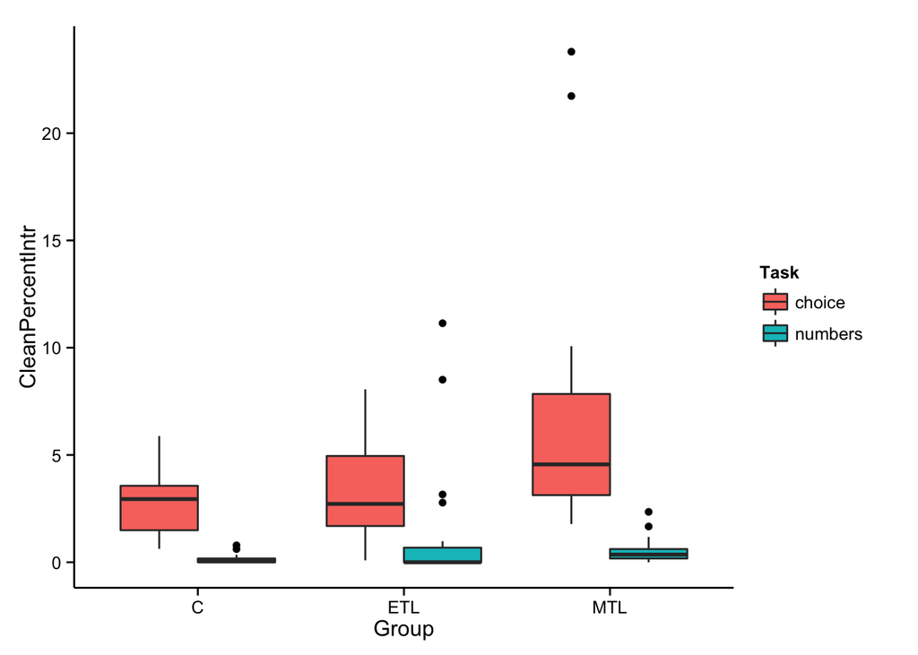

```r
ggplot(data = both.Intransitive, aes(x = Group, y = CleanPercentIntr, fill = Task))+
  geom_boxplot()+
  theme_classic()
```

The first thing we could do would be a one-way anova for both tasks.

```r
summary(aov(CleanPercentIntr ~ Group, data = both.Intransitive[both.Intransitive$Task == "choice",]))
```

```
##             Df Sum Sq Mean Sq F value  Pr(>F)
## Group        2    190    95.2    8.83 0.00032 ***
## Residuals   88    948    10.8
## ---
## Signif. codes:  0 '***' 0.001 '**' 0.01 '*' 0.05 '.' 0.1 ' ' 1
```

```r
summary(aov(CleanPercentIntr ~ Group, data = both.Intransitive[both.Intransitive$Task == "numbers",]))
```

```
##             Df Sum Sq Mean Sq F value Pr(>F)
## Group        2   11.2    5.62    2.51  0.087 .
## Residuals   88  197.0    2.24
## ---
## Signif. codes:  0 '***' 0.001 '**' 0.01 '*' 0.05 '.' 0.1 ' ' 1
```

```r
summary(aov(CleanPercentIntr ~ Group*Task, data = both.Intransitive))
```

```
##              Df Sum Sq Mean Sq F value  Pr(>F)
## Group         2    105      52    8.05 0.00045 ***
## Task          1    569     569   87.47 < 2e-16 ***
## Group:Task    2     97      48    7.44 0.00079 ***
## Residuals   176   1145       7
## ---
## Signif. codes:  0 '***' 0.001 '**' 0.01 '*' 0.05 '.' 0.1 ' ' 1
```

We would get a sig group difference in the choice task, non-sig diff in the numbers task looking at them separately and also a group task interaction if we were looking at them together.

**PROBLEM: NORMALITY ASSUMPTION IS VIOLATED**

The distribution of effect sizes within tasks is not normal for either task. This is why we can’t use ANOVA to test for group differences within tasks.

```
## stat_bin: binwidth defaulted to range/30. Use 'binwidth = x' to adjust this.
```

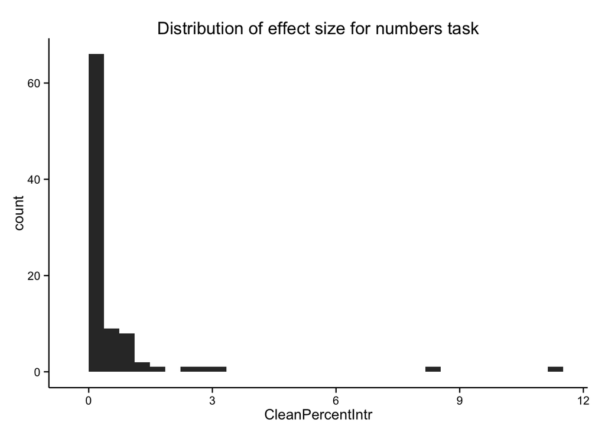

```r
ggplot(both.Intransitive[both.Intransitive$Task == "numbers",], aes(CleanPercentIntr))+
  geom_histogram()+
  theme_classic()+
  ggtitle("Distribution of effect size for numbers task")
```

```r
shapiro.test(both.Intransitive[both.Intransitive$Task == "numbers",]$CleanPercentIntr)
```

```
##
##  Shapiro-Wilk normality test
##
## data:  both.Intransitive[both.Intransitive$Task == "numbers", ]$CleanPercentIntr
## W = 0.3569, p-value < 2.2e-16
```

```
## stat_bin: binwidth defaulted to range/30. Use 'binwidth = x' to adjust this.
```

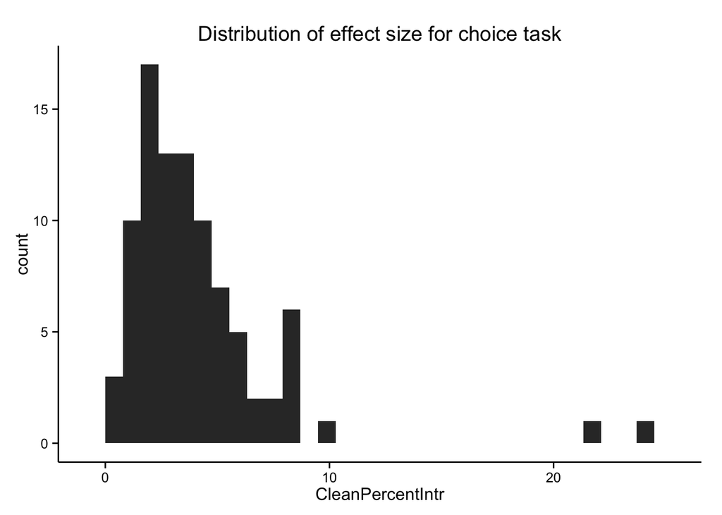

```r
ggplot(both.Intransitive[both.Intransitive$Task == "choice",], aes(CleanPercentIntr))+
  geom_histogram()+
  theme_classic()+
  ggtitle("Distribution of effect size for choice task")
```

```r
shapiro.test(both.Intransitive[both.Intransitive$Task == "choice",]$CleanPercentIntr)
```

```
##
##  Shapiro-Wilk normality test
##
## data:  both.Intransitive[both.Intransitive$Task == "choice", ]$CleanPercentIntr
## W = 0.6899, p-value = 1.441e-12
```

**SOLUTION?: NON-PARAMETRIC TEST?**

For choice task: sig group differences. MTL higher than both groups.

```r
kruskal.test(CleanIntr ~ Group, data=both.Intransitive[both.Intransitive$Task == "choice",])
```

```
##
##  Kruskal-Wallis rank sum test
##
## data:  CleanIntr by Group
## Kruskal-Wallis chi-squared = 13.6, df = 2, p-value = 0.001112
```

```r
pairwise.wilcox.test(both.Intransitive[both.Intransitive$Task == "choice",]$CleanIntr, both.Intransitive[both.Intransitive$Task == "choice",]$Group, p.adj="bonferroni", exact=F)
```

```
##
##  Pairwise comparisons using Wilcoxon rank sum test
##
## data:  both.Intransitive[both.Intransitive$Task == "choice", ]$CleanIntr and both.Intransitive[both.Intransitive$Task == "choice", ]$Group
##
##     C      ETL
## ETL 1.0000 -
## MTL 0.0013 0.0253
##
## P value adjustment method: bonferroni
```

For numbers task: Sig group differences here too (not preferred). MTL higher than controls.

```r
kruskal.test(CleanIntr ~ Group, data=both.Intransitive[both.Intransitive$Task == "numbers",])
```

```
##
##  Kruskal-Wallis rank sum test
##
## data:  CleanIntr by Group
## Kruskal-Wallis chi-squared = 12.43, df = 2, p-value = 0.002
```

```r
pairwise.wilcox.test(both.Intransitive[both.Intransitive$Task == "numbers",]$CleanIntr, both.Intransitive[both.Intransitive$Task == "numbers",]$Group, p.adj="bonferroni", exact=F)
```

```
##
##  Pairwise comparisons using Wilcoxon rank sum test
##
## data:  both.Intransitive[both.Intransitive$Task == "numbers", ]$CleanIntr and both.Intransitive[both.Intransitive$Task == "numbers", ]$Group
##
##     C       ETL
## ETL 1.00000 -
## MTL 0.00081 0.07651
##
## P value adjustment method: bonferroni
```

**PROBLEM 1: WE CAN’T CHECK THE INTERACTION OF GROUP BY TASK KRUSKAL-WALLIS**

**PROBLEM 2: UNEQUAL VARIANCE IN DISTRIBUTION OF EFFECT SIZE BETWEEN THE TASKS**

As the Bartlett test and the plot shows variance in effect size is not independent of task.

```r
#The variances between the two tasks are very different!
var(both.Intransitive[both.Intransitive$Task == "numbers",]$CleanPercentIntr)
```

```
## [1] 2.314
```

```r
var(both.Intransitive[both.Intransitive$Task == "choice",]$CleanPercentIntr)
```

```
## [1] 12.65
```

```r
#Significantly so? YES! (the more important/problematic issue is this)

#The distribution of the effect size is not independent of the task!
bartlett.test(CleanPercentIntr ~ Task, data = both.Intransitive)
```

```
##
##  Bartlett test of homogeneity of variances
##
## data:  CleanPercentIntr by Task
## Bartlett's K-squared = 58.05, df = 1, p-value = 2.549e-14
```

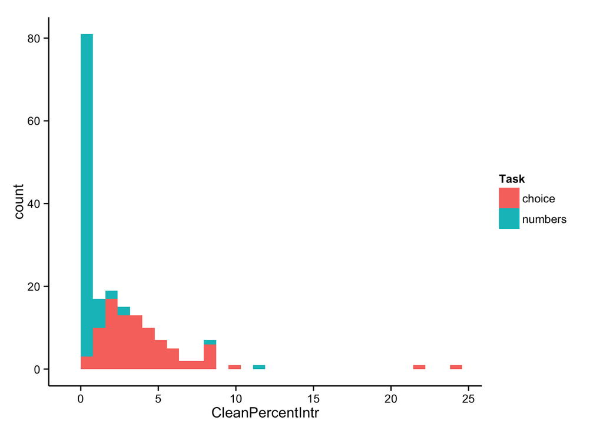

```r
ggplot(both.Intransitive, aes(CleanPercentIntr, fill = Task))+
  geom_histogram()+
  theme_classic()
```

**SOLUTION: TRANSFORM DV AND RUN REGRESSIONS**

Which is best? Go with log..

Log transform spreads the variance in the numbers enough to make the difference in variance almost independent of task.

```r
# bartlett.test(sqrt(CleanPercentIntr) ~ Task, data = both.Intransitive) #marginal

bartlett.test(log(CleanPercentIntr + 1) ~ Task, data = both.Intransitive) #even less marginal
```

```
##
##  Bartlett test of homogeneity of variances
##
## data:  log(CleanPercentIntr + 1) by Task
## Bartlett's K-squared = 3.354, df = 1, p-value = 0.06705
```

```
## stat_bin: binwidth defaulted to range/30. Use 'binwidth = x' to adjust this.
```

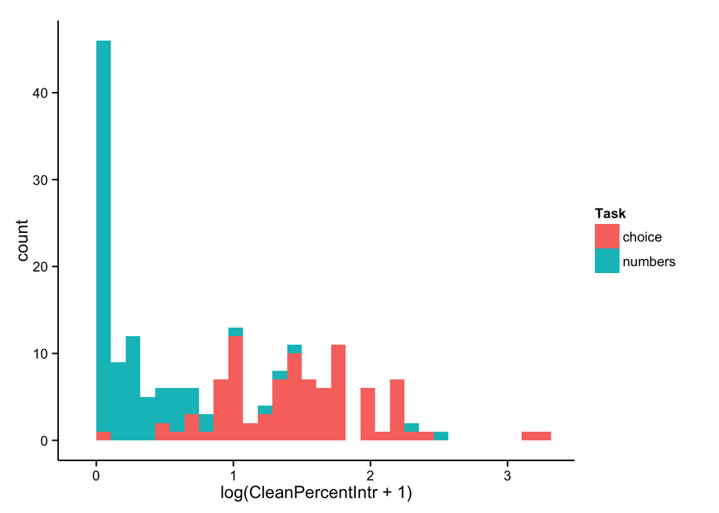

```r
# bartlett.test(((-1)/(CleanPercentIntr+0.001)) ~ Task, data = both.Intransitive) #Doesn't work

ggplot(both.Intransitive, aes(log(CleanPercentIntr + 1), fill = Task))+
  geom_histogram()+
  theme_classic()
```

Step back and think about what you are interested in. First plot the data:

```r
#GOOD PLOT!
se <- function(x) sd(x)/sqrt(length(x))

plot.Intransitive.df <- ddply(both.Intransitive, .(Task, Group), summarise,
      MeanCleanPercentIntr = mean(CleanPercentIntr, na.rm=T),
      SeCleanPercentIntr = se(CleanPercentIntr),
      eb.low = MeanCleanPercentIntr - SeCleanPercentIntr,
      eb.high = MeanCleanPercentIntr + SeCleanPercentIntr)
plot.Intransitive.df
```

```
##      Task Group MeanCleanPercentIntr SeCleanPercentIntr eb.low eb.high
## 1  choice     C               2.7503            0.25748 2.4929  3.0078
## 2  choice   ETL               3.3738            0.39376 2.9800  3.7675
## 3  choice   MTL               6.0669            0.90152 5.1654  6.9685
## 4 numbers     C               0.1404            0.03632 0.1041  0.1767
## 5 numbers   ETL               1.0025            0.46430 0.5382  1.4668
## 6 numbers   MTL               0.5044            0.09447 0.4099  0.5988
```

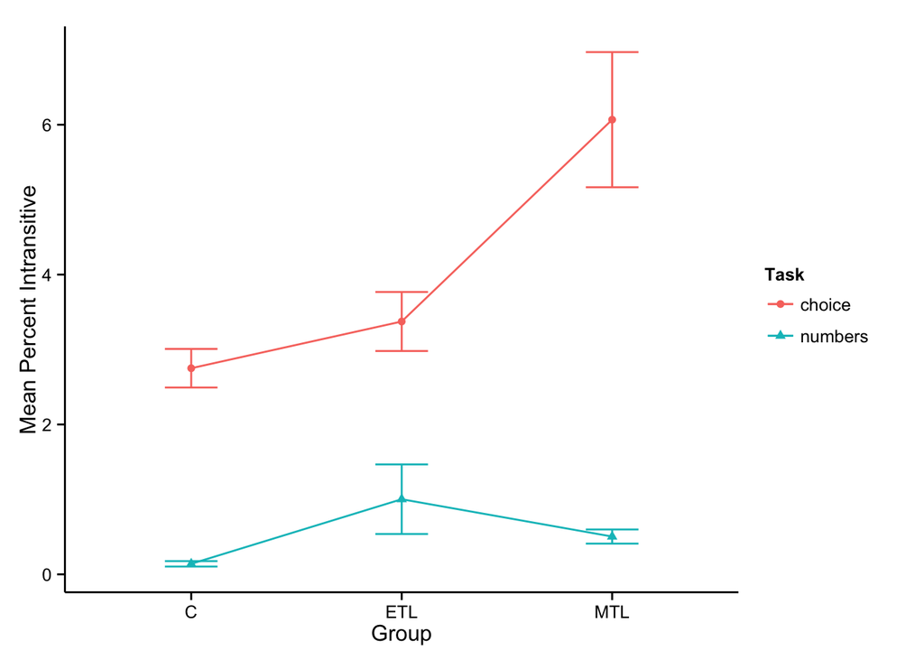

```r
#With color
limits <- aes(ymax = plot.Intransitive.df$eb.high, ymin=plot.Intransitive.df$eb.low)
#Error bars are SEMs
ggplot(data = plot.Intransitive.df, aes(x = Group, y=MeanCleanPercentIntr, group = Task, col = Task))+
  geom_point(aes(shape =Task))+
  geom_line()+
  geom_errorbar(limits, width=0.25)+
  theme_classic()+
  ylab("Mean Percent Intransitive")
```

```r
#For poster
ggplot(data = plot.Intransitive.df, aes(x = Group, y=MeanCleanPercentIntr, group = Task))+
  geom_point(aes(shape = Task))+
  geom_line(aes(linetype = Task))+
  geom_errorbar(limits, width=0.25)+
  ylab("Mean Percentage of Intransitivities")+
  xlab("")+
  theme_classic()+
  theme(axis.title.y = element_text(face="bold", size = 20),
           axis.text.x  = element_text(face="bold", size = 20),
        legend.text = element_text(size = 20),
        legend.title = element_text(size = 20))
```

Looking at the plot what are we interested in? Whether the difference between the red and blue curves is the same for all groups. In other words: Is there a significant intereaction between task and group, i.e. is the effect of changing the task same for the MTL group as it is for the control groups.

(**Using transformed DVs!**): The interactive model is the best fitting model!

```r
gm1a <- lm(log(CleanPercentIntr+1) ~ Task, both.Intransitive)#; summary(gm1a)
gm1b <- lm(log(CleanPercentIntr+1) ~ Group, both.Intransitive)# ; summary(gm1b)
gm2 <- lm(log(CleanPercentIntr+1) ~ Group+Task, both.Intransitive)# ; summary(gm2)
gm3 <- lm(log(CleanPercentIntr+1) ~ Group*Task, both.Intransitive)# ; summary(gm3)
#Interactive model is always better!
anova(gm1a, gm2, gm3)
```

```
## Analysis of Variance Table
##
## Model 1: log(CleanPercentIntr + 1) ~ Task
## Model 2: log(CleanPercentIntr + 1) ~ Group + Task
## Model 3: log(CleanPercentIntr + 1) ~ Group * Task
##   Res.Df  RSS Df Sum of Sq     F  Pr(>F)
## 1    180 43.5
## 2    178 38.8  2      4.74 11.22 2.6e-05 ***
## 3    176 37.2  2      1.57  3.72   0.026 *
## ---
## Signif. codes:  0 '***' 0.001 '**' 0.01 '*' 0.05 '.' 0.1 ' ' 1
```

```r
anova(gm1b, gm2, gm3)
```

```
## Analysis of Variance Table
##
## Model 1: log(CleanPercentIntr + 1) ~ Group
## Model 2: log(CleanPercentIntr + 1) ~ Group + Task
## Model 3: log(CleanPercentIntr + 1) ~ Group * Task
##   Res.Df   RSS Df Sum of Sq      F Pr(>F)
## 1    179 103.0
## 2    178  38.8  1      64.2 303.80 <2e-16 ***
## 3    176  37.2  2       1.6   3.72  0.026 *
## ---
## Signif. codes:  0 '***' 0.001 '**' 0.01 '*' 0.05 '.' 0.1 ' ' 1
```

So what does it say? Look at the contrasts first!

```r
contrasts(both.Intransitive$Task)
```

```
##         numbers
## choice        0
## numbers       1
```

```r
contrasts(both.Intransitive$Group)
```

```
##     ETL MTL
## C     0   0
## ETL   1   0
## MTL   0   1
```

```r
summary(gm3)
```

```
##
## Call:
## lm(formula = log(CleanPercentIntr + 1) ~ Group * Task, data = both.Intransitive)
##
## Residuals:
##     Min      1Q  Median      3Q     Max
## -1.2678 -0.3590 -0.0785  0.2261  2.1345
##
## Coefficients:
##                      Estimate Std. Error t value Pr(>|t|)
## (Intercept)            1.2508     0.0839   14.90  < 2e-16 ***
## GroupETL               0.1011     0.1187    0.85    0.395
## GroupMTL               0.5441     0.1178    4.62  7.4e-06 ***
## Tasknumbers           -1.1322     0.1187   -9.54  < 2e-16 ***
## GroupETL:Tasknumbers   0.1422     0.1679    0.85    0.398
## GroupMTL:Tasknumbers  -0.3019     0.1665   -1.81    0.072 .
## ---
## Signif. codes:  0 '***' 0.001 '**' 0.01 '*' 0.05 '.' 0.1 ' ' 1
##
## Residual standard error: 0.46 on 176 degrees of freedom
## Multiple R-squared:  0.655,  Adjusted R-squared:  0.645
## F-statistic: 66.7 on 5 and 176 DF,  p-value: <2e-16
```

b0 = mean intrans for both tasks for the C group is >0 (not interesting) b1 = ETL group doesn’t make sig more intrans in CHOICE task! (good) - simple effect b2 = MTL group DOES make sig more intrans in CHOICE task! (good) - simple effect b3 = C group makes sig less intrans in NUMBERS task! (not surprising, easy task) b4 = Is the effect of task in ETL group same as C. Yes. b5 = Is the effect of task in MTL group same as C. Marginally no.

**PROBLEM: These are not orthogonal contrasts and is comparing both groups to Healthy controls only!**

**SOLUTION:ORTHOGONALIZE CONTRASTS**

If we change the contrasts and make them orthogonal there would be no overlapping variance (and seems like answer our question of interest perhaps slightly more indirectly but possibly more fully). We would first compare the ETL group to the C group and then the MTL group to BOTH CONTROL GROUPS!

```r
#Change the contrasts, make them orthogonal
both.Intransitive.contrast <- both.Intransitive
contrasts(both.Intransitive.contrast$Group) <- cbind(c(-1,1, 0), c(-1, -1, 2))
contrasts(both.Intransitive.contrast$Task) <- c(-1, 1)

contrasts(both.Intransitive.contrast$Task)
```

```
##         [,1]
## choice    -1
## numbers    1
```

```r
contrasts(both.Intransitive.contrast$Group)
```

```
##     [,1] [,2]
## C     -1   -1
## ETL    1   -1
## MTL    0    2
```

```r
gm3.con <- lm(log(CleanPercentIntr+1) ~ Group*Task, both.Intransitive.contrast)
summary(gm3.con)
```

```
##
## Call:
## lm(formula = log(CleanPercentIntr + 1) ~ Group * Task, data = both.Intransitive.contrast)
##
## Residuals:
##     Min      1Q  Median      3Q     Max
## -1.2678 -0.3590 -0.0785  0.2261  2.1345
##
## Coefficients:
##              Estimate Std. Error t value Pr(>|t|)
## (Intercept)    0.8732     0.0341   25.62  < 2e-16 ***
## Group1         0.0861     0.0420    2.05    0.042 *
## Group2         0.1023     0.0240    4.27  3.2e-05 ***
## Task1         -0.5927     0.0341  -17.39  < 2e-16 ***
## Group1:Task1   0.0356     0.0420    0.85    0.398
## Group2:Task1  -0.0622     0.0240   -2.59    0.010 *
## ---
## Signif. codes:  0 '***' 0.001 '**' 0.01 '*' 0.05 '.' 0.1 ' ' 1
##
## Residual standard error: 0.46 on 176 degrees of freedom
## Multiple R-squared:  0.655,  Adjusted R-squared:  0.645
## F-statistic: 66.7 on 5 and 176 DF,  p-value: <2e-16
```

What does the model say now:

b0 = Unweighted grand mean (mean of group means) (sum(aggregate(CleanPercentIntr ~ Group, both.Intransitive.contrast, mean)[,2])/3) b1 = Total group effect for ETL compared to healthy controls only (quantified) b2 = Total group effect for MTL compared to both control groups (quantified) b3 = Total task effect b4 = Is the effect of task change same for ETL and C groups? (yes.) b5 = Is the effect of task change same for MTL vs both control groups? (No!)

Looking at group differences within tasks would be simple effects from this perspective. We can look at them again (though I do not think they are necessary to report).

```r
#Simple effect of group
#Create dummy variables for simple effects instead of changing the contrast in the df
both.Intransitive.contrast$number <- ifelse(both.Intransitive.contrast$Task == "numbers",1,0)
both.Intransitive.contrast$choice <- ifelse(both.Intransitive.contrast$Task == "choice",1,0)
#Simple effect of group for choice task: MTL (Group 2) significantly higher!
gm3.con.sc <- lm(log(CleanPercentIntr+1) ~ Group*number, both.Intransitive.contrast); summary(gm3.con.sc)
```

```
##
## Call:
## lm(formula = log(CleanPercentIntr + 1) ~ Group * number, data = both.Intransitive.contrast)
##
## Residuals:
##     Min      1Q  Median      3Q     Max
## -1.2678 -0.3590 -0.0785  0.2261  2.1345
##
## Coefficients:
##               Estimate Std. Error t value Pr(>|t|)
## (Intercept)     1.4659     0.0482   30.41  < 2e-16 ***
## Group1          0.0506     0.0594    0.85     0.40
## Group2          0.1645     0.0339    4.85  2.7e-06 ***
## number         -1.1854     0.0682  -17.39  < 2e-16 ***
## Group1:number   0.0711     0.0839    0.85     0.40
## Group2:number  -0.1243     0.0479   -2.59     0.01 *
## ---
## Signif. codes:  0 '***' 0.001 '**' 0.01 '*' 0.05 '.' 0.1 ' ' 1
##
## Residual standard error: 0.46 on 176 degrees of freedom
## Multiple R-squared:  0.655,  Adjusted R-squared:  0.645
## F-statistic: 66.7 on 5 and 176 DF,  p-value: <2e-16
```

```r
#Simple effect of group for number task: ETL (Group 1) significantly (marg?) higher
gm3.con.sn <- lm(log(CleanPercentIntr+1) ~ Group*choice, both.Intransitive.contrast); summary(gm3.con.sn)
```

```
##
## Call:
## lm(formula = log(CleanPercentIntr + 1) ~ Group * choice, data = both.Intransitive.contrast)
##
## Residuals:
##     Min      1Q  Median      3Q     Max
## -1.2678 -0.3590 -0.0785  0.2261  2.1345
##
## Coefficients:
##               Estimate Std. Error t value Pr(>|t|)
## (Intercept)     0.2805     0.0482    5.82  2.8e-08 ***
## Group1          0.1217     0.0594    2.05    0.042 *
## Group2          0.0402     0.0339    1.18    0.238
## choice          1.1854     0.0682   17.39  < 2e-16 ***
## Group1:choice  -0.0711     0.0839   -0.85    0.398
## Group2:choice   0.1243     0.0479    2.59    0.010 *
## ---
## Signif. codes:  0 '***' 0.001 '**' 0.01 '*' 0.05 '.' 0.1 ' ' 1
##
## Residual standard error: 0.46 on 176 degrees of freedom
## Multiple R-squared:  0.655,  Adjusted R-squared:  0.645
## F-statistic: 66.7 on 5 and 176 DF,  p-value: <2e-16
```

The simple effects suggest that the MTl group had a significantly higher percentage of intransitivities in the choice task compared to both control groups and the ETL group has sig more intransitivities in the numbers task compared to the healthy controls (only).

*PROBLEM: REPEATED MEASURES*

Two measures from each participant. Tasks are not between subjects.

*SOLUTION: MIXED MODEL*

Checking if mixed model necessary: Yes it is.

```r
# summary(aov(log(CleanPercentIntr+1) ~ Group*Task + Error(f.id/Task) + Group, both.Intransitive))
#Within group var looks very small compared to between groups?

gm3.lmer.con <- lmerTest::lmer(log(CleanPercentIntr+1) ~ Group*Task + (1|f.id), both.Intransitive.contrast, REML = F)

summary(gm3.lmer.con)
```

```
## Linear mixed model fit by maximum likelihood t-tests use Satterthwaite
##   approximations to degrees of freedom [merModLmerTest]
## Formula: log(CleanPercentIntr + 1) ~ Group * Task + (1 | f.id)
##    Data: both.Intransitive.contrast
##
##      AIC      BIC   logLik deviance df.resid
##    239.2    264.8   -111.6    223.2      174
##
## Scaled residuals:
##    Min     1Q Median     3Q    Max
## -2.442 -0.601 -0.152  0.543  4.294
##
## Random effects:
##  Groups   Name        Variance Std.Dev.
##  f.id     (Intercept) 0.0444   0.211
##  Residual             0.1601   0.400
## Number of obs: 182, groups:  f.id, 91
##
## Fixed effects:
##              Estimate Std. Error      df t value Pr(>|t|)
## (Intercept)    0.8732     0.0370 91.0000   23.61  < 2e-16 ***
## Group1         0.0861     0.0455 91.0000    1.89  0.06175 .
## Group2         0.1023     0.0260 91.0000    3.93  0.00016 ***
## Task1         -0.5927     0.0297 91.0000  -19.98  < 2e-16 ***
## Group1:Task1   0.0356     0.0365 91.0000    0.97  0.33288
## Group2:Task1  -0.0622     0.0209 91.0000   -2.98  0.00369 **
## ---
## Signif. codes:  0 '***' 0.001 '**' 0.01 '*' 0.05 '.' 0.1 ' ' 1
##
## Correlation of Fixed Effects:
##             (Intr) Group1 Group2 Task1  Gr1:T1
## Group1       0.000
## Group2      -0.015  0.000
## Task1        0.000  0.000  0.000
## Group1:Tsk1  0.000  0.000  0.000  0.000
## Group2:Tsk1  0.000  0.000  0.000 -0.015  0.000
```

```r
x2 = -2*logLik(gm3.con) +2*logLik(gm3.lmer.con)
x2
```

```
## 'log Lik.' 4.39 (df=7)
```

```r
pchisq(x2, df=1, lower.tail=F)
```

```
## 'log Lik.' 0.03614 (df=7)
```

```r
#Simple effects in lmer of group in numbers task
gm3.lmer.con.sn <- lmerTest::lmer(log(CleanPercentIntr+1) ~ Group*choice + (1|f.id), both.Intransitive.contrast)
summary(gm3.lmer.con.sn)
```

```
## Linear mixed model fit by REML t-tests use Satterthwaite approximations
##   to degrees of freedom [merModLmerTest]
## Formula: log(CleanPercentIntr + 1) ~ Group * choice + (1 | f.id)
##    Data: both.Intransitive.contrast
##
## REML criterion at convergence: 249.4
##
## Scaled residuals:
##    Min     1Q Median     3Q    Max
## -2.402 -0.591 -0.149  0.534  4.222
##
## Random effects:
##  Groups   Name        Variance Std.Dev.
##  f.id     (Intercept) 0.0459   0.214
##  Residual             0.1655   0.407
## Number of obs: 182, groups:  f.id, 91
##
## Fixed effects:
##               Estimate Std. Error       df t value Pr(>|t|)
## (Intercept)     0.2805     0.0482 168.1000    5.82  2.9e-08 ***
## Group1          0.1217     0.0594 168.1000    2.05   0.0419 *
## Group2          0.0402     0.0339 168.1000    1.18   0.2378
## choice          1.1854     0.0603  88.0000   19.65  < 2e-16 ***
## Group1:choice  -0.0711     0.0743  88.0000   -0.96   0.3410
## Group2:choice   0.1243     0.0424  88.0000    2.93   0.0043 **
## ---
## Signif. codes:  0 '***' 0.001 '**' 0.01 '*' 0.05 '.' 0.1 ' ' 1
##
## Correlation of Fixed Effects:
##             (Intr) Group1 Group2 choice Grp1:c
## Group1       0.000
## Group2      -0.015  0.000
## choice      -0.626  0.000  0.010
## Group1:choc  0.000 -0.626  0.000  0.000
## Group2:choc  0.010  0.000 -0.626 -0.015  0.000
```

```r
#(You can see how the contrasts are not orthogonal in the correlation of fixed effects)
```

### CONCLUSION

Running a linear mixed model with orthogonal contrasts is the most appropriate analysis and reveals a significant group task interaction in the percentage of intransitivities. Accordingly the MTL group had a higher percentage of intransitivities in the choice task than the numbers task compared to both control groups, while the difference between the percentage of intransitivities did not differ between tasks between the health controls and the ETL group.

## SOM Analyses

### Response times

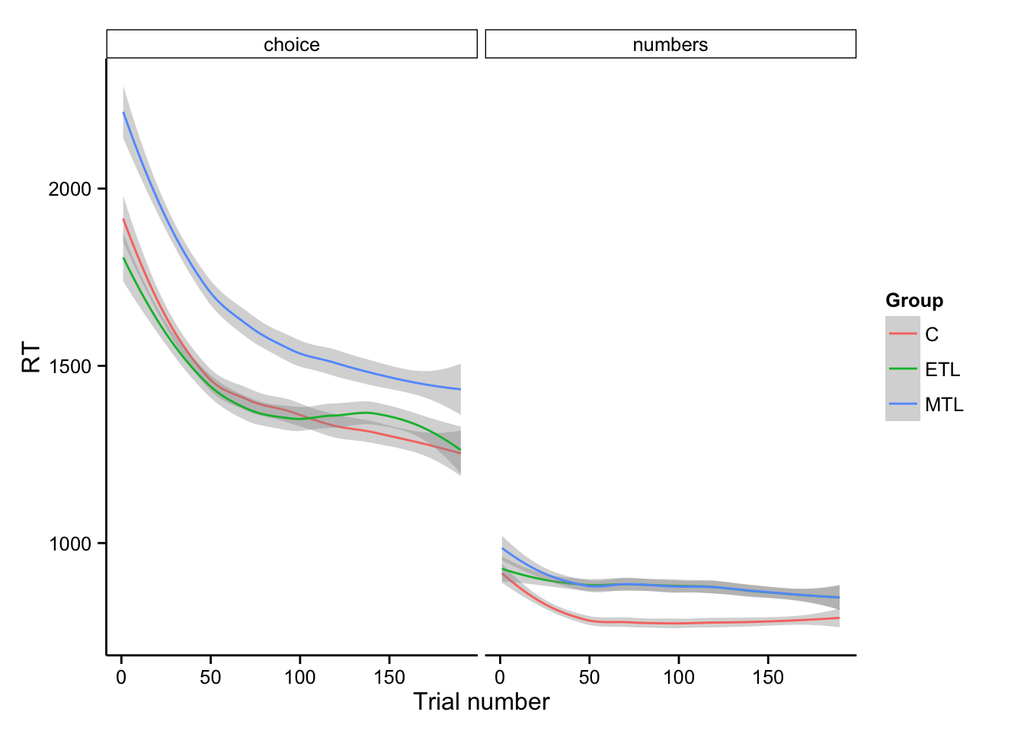

```r
choice2.trial.data$Task <- "choice"
numbers.trial.data$Task <- "numbers"

RT.df <- rbind(choice2.trial.data[,c("f.id", "Group", "RT", "Task", "Trialnumber", "IntransTripleCounted")], numbers.trial.data[,c("f.id", "Group", "RT", "Task", "Trialnumber", "IntransTripleCounted")])
RT.df$Task <- as.factor(RT.df$Task)

ggplot(data = RT.df[RT.df$RT>0,], aes(x = Trialnumber, y = RT, group = Group, col = Group))+
  geom_smooth(method = "loess")+
  theme_classic()+
  facet_grid(~Task)+
  xlab("Trial number")
```

```r
rt.lmer1 <- lmerTest::lmer(RT ~ Group*Task*Trialnumber + (1|f.id), data = RT.df[RT.df$RT>0,])

#Three way interaction is sig better..
# rt.lmer2 <- lmerTest::lmer(RT ~ Group*Task + Trialnumber + (1|f.id), data = RT.df[RT.df$RT>0,])

# anova(rt.lmer1, rt.lmer2)

#Don't need random slopes for groups
# rt.lmer3 <- lmerTest::lmer(RT ~ Group*Task*Trialnumber + (Group|f.id), data = RT.df[RT.df$RT>0,])
#
# anova(rt.lmer1, rt.lmer3)

summary(rt.lmer1)
```

```
## Linear mixed model fit by REML t-tests use Satterthwaite approximations
##   to degrees of freedom [merModLmerTest]
## Formula: RT ~ Group * Task * Trialnumber + (1 | f.id)
##    Data: RT.df[RT.df$RT > 0, ]
##
## REML criterion at convergence: 521063
##
## Scaled residuals:
##    Min     1Q Median     3Q    Max
## -4.514 -0.592 -0.122  0.319 14.604
##
## Random effects:
##  Groups   Name        Variance Std.Dev.
##  f.id     (Intercept)  74810   274
##  Residual             226590   476
## Number of obs: 34325, groups:  f.id, 91
##
## Fixed effects:
##                                   Estimate Std. Error        df t value
## (Intercept)                       1660.484     51.532    98.000   32.22
## GroupETL                           -60.632     72.882    98.000   -0.83
## GroupMTL                           286.035     72.312    98.000    3.96
## Tasknumbers                       -837.090     17.952 34225.000  -46.63
## Trialnumber                         -2.527      0.115 34225.000  -21.90
## GroupETL:Tasknumbers               142.399     25.408 34225.000    5.60
## GroupMTL:Tasknumbers              -186.445     25.293 34225.000   -7.37
## GroupETL:Trialnumber                 0.655      0.163 34225.000    4.01
## GroupMTL:Trialnumber                -0.767      0.163 34225.000   -4.72
## Tasknumbers:Trialnumber              2.190      0.163 34225.000   13.44
## GroupETL:Tasknumbers:Trialnumber    -0.619      0.231 34225.000   -2.69
## GroupMTL:Tasknumbers:Trialnumber     0.663      0.229 34225.000    2.89
##                                  Pr(>|t|)
## (Intercept)                       < 2e-16 ***
## GroupETL                          0.40747
## GroupMTL                          0.00014 ***
## Tasknumbers                       < 2e-16 ***
## Trialnumber                       < 2e-16 ***
## GroupETL:Tasknumbers              2.1e-08 ***
## GroupMTL:Tasknumbers              1.7e-13 ***
## GroupETL:Trialnumber              6.1e-05 ***
```

[output cut: 17 more lines]

```
## Tsknmbrs:Tr  0.152 -0.107 -0.108 -0.868 -0.708  0.613     0.616
## GrpETL:Ts:T -0.107  0.152  0.076  0.613  0.500 -0.868    -0.435
## GrpMTL:Ts:T -0.108  0.076  0.153  0.616  0.503 -0.435    -0.868
##             GrpETL:Tr GrpMTL:Tr Tskn:T GETL:T:
## GroupETL
## GroupMTL
## Tasknumbers
## Trialnumber
## GrpETL:Tskn
## GrpMTL:Tskn
## GrpETL:Trln
## GrpMTL:Trln  0.501
## Tsknmbrs:Tr  0.500     0.503
## GrpETL:Ts:T -0.708    -0.355    -0.707
## GrpMTL:Ts:T -0.355    -0.709    -0.710  0.502
```

```r
aggregate(RT ~ Group + Task, data = RT.df[RT.df$RT>0,], FUN = mean)
```

```
##   Group    Task     RT
## 1     C  choice 1418.2
## 2   ETL  choice 1419.0
## 3   MTL  choice 1624.9
## 4     C numbers  791.1
## 5   ETL numbers  876.2
## 6   MTL numbers  880.0
```

```r
rm(RT.df)
```

### Intransitivities by groups

(see above for rest of the stats in this section (e.g. model comparison for lmer and Bartlett test))

```r
summary(choice2.trial.data$IntransTripleCounted)
```

```
##    Min. 1st Qu.  Median    Mean 3rd Qu.    Max.
##   0.000   0.000   0.000   0.715   1.000  17.000
```

```r
sd(choice2.trial.data$IntransTripleCounted)
```

```
## [1] 1.414
```

```r
summary(both.Intransitive$CleanIntr[both.Intransitive$Task == "choice"])
```

```
##    Min. 1st Qu.  Median    Mean 3rd Qu.    Max.
##     1.0    21.0    37.0    44.7    54.0   267.0
```

```r
sd(both.Intransitive$CleanIntr[both.Intransitive$Task == "choice"])
```

```
## [1] 39.37
```

### Preference for side of computer screen

```r
left.df <- rbind(choice2.trial.data[,c("f.id", "Group", "RT","Choice.left1.right0", "Task", "IntransTripleCounted")], numbers.trial.data[,c("f.id", "Group", "RT","Choice.left1.right0", "Task", "IntransTripleCounted")])
left.df$Task <- as.factor(left.df$Task)

mean(left.df$Choice.left1.right0[left.df$RT>0], na.rm=T)
```

```
## [1] 0.502
```

```r
aggregate(Choice.left1.right0 ~ Group*Task, data = left.df[left.df$RT>0,], mean)
```

```
##   Group    Task Choice.left1.right0
## 1     C  choice              0.5120
## 2   ETL  choice              0.5073
## 3   MTL  choice              0.4882
## 4     C numbers              0.4986
## 5   ETL numbers              0.4964
## 6   MTL numbers              0.5097
```

```r
se <- function(x) sd(x, na.rm=T)/sqrt(length(x))

plot.left.df <- ddply(left.df[left.df$RT>0,], .(Task, Group), summarise,
      MeanChoice.left1.right0 = mean(Choice.left1.right0, na.rm=T),
      SeChoice.left1.right0 = se(Choice.left1.right0),
      eb.low = MeanChoice.left1.right0 - SeChoice.left1.right0,
      eb.high = MeanChoice.left1.right0 + SeChoice.left1.right0)
plot.left.df
```

```
##      Task Group MeanChoice.left1.right0 SeChoice.left1.right0 eb.low
## 1  choice     C                  0.5120              0.006634 0.5053
## 2  choice   ETL                  0.5073              0.006649 0.5007
## 3  choice   MTL                  0.4882              0.006592 0.4816
## 4 numbers     C                  0.4986              0.006624 0.4920
## 5 numbers   ETL                  0.4964              0.006635 0.4898
## 6 numbers   MTL                  0.5097              0.006529 0.5032
##   eb.high
## 1  0.5186
## 2  0.5140
## 3  0.4948
## 4  0.5052
## 5  0.5030
## 6  0.5162
```

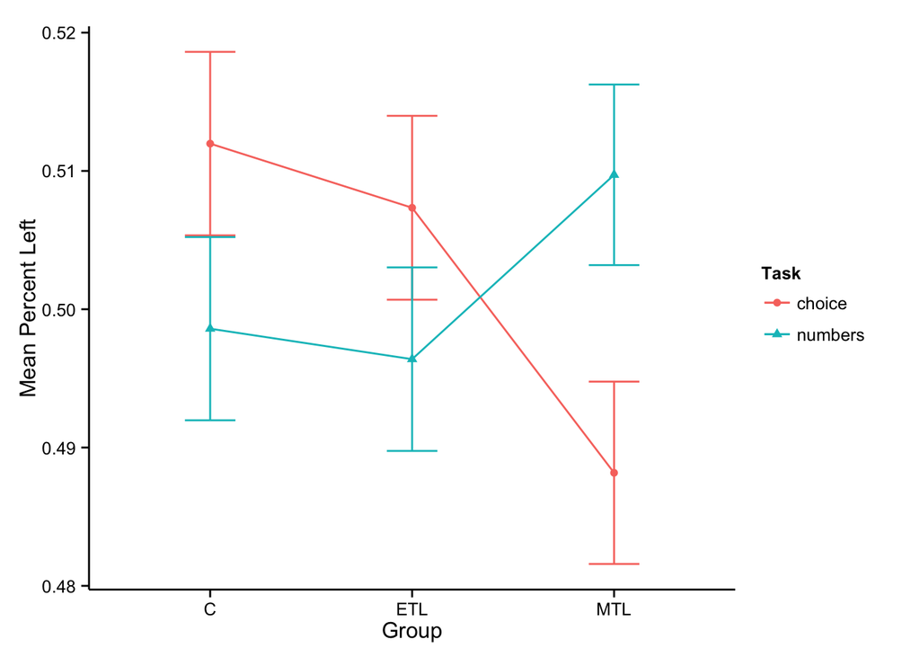

```r
#With color
limits <- aes(ymax = plot.left.df$eb.high, ymin=plot.left.df$eb.low)
#Error bars are SEMs
ggplot(data = plot.left.df, aes(x = Group, y=MeanChoice.left1.right0, group = Task, col = Task))+
  geom_point(aes(shape =Task))+
  geom_line()+
  geom_errorbar(limits, width=0.25)+
  theme_classic()+
  ylab("Mean Percent Left")
```

```r
summary(aov(Choice.left1.right0 ~ Group, data=left.df[left.df$RT>0 & left.df$Task == "choice",]))
```

```
##                Df Sum Sq Mean Sq F value Pr(>F)
## Group           2      2   0.911    3.65  0.026 *
## Residuals   17080   4269   0.250
## ---
## Signif. codes:  0 '***' 0.001 '**' 0.01 '*' 0.05 '.' 0.1 ' ' 1
## 1 observation deleted due to missingness
```

```r
pairwise.t.test(left.df[left.df$RT>0 & left.df$Task == "choice",]$Choice.left1.right0, left.df[left.df$RT>0 & left.df$Task == "choice",]$Group, p.adjust = "bonferroni")
```

```
##
##  Pairwise comparisons using t tests with pooled SD
##
## data:  left.df[left.df$RT > 0 & left.df$Task == "choice", ]$Choice.left1.right0 and left.df[left.df$RT > 0 & left.df$Task == "choice", ]$Group
##
##     C     ETL
## ETL 1.000 -
## MTL 0.033 0.122
##
## P value adjustment method: bonferroni
```

```r
left.lmer1 <- glmer(Choice.left1.right0 ~ Group*Task + (1|f.id), data = left.df[left.df$RT>0,], family = binomial)
summary(left.lmer1)
```

```
## Generalized linear mixed model fit by maximum likelihood (Laplace
##   Approximation) [glmerMod]
##  Family: binomial  ( logit )
## Formula: Choice.left1.right0 ~ Group * Task + (1 | f.id)
##    Data: left.df[left.df$RT > 0, ]
##
##      AIC      BIC   logLik deviance df.resid
##    47582    47641   -23784    47568    34317
##
## Scaled residuals:
##    Min     1Q Median     3Q    Max
## -1.055 -1.003  0.948  0.995  1.067
##
## Random effects:
##  Groups Name        Variance Std.Dev.
##  f.id   (Intercept) 0.0038   0.0616
## Number of obs: 34324, groups:  f.id, 91
##
## Fixed effects:
##                      Estimate Std. Error z value Pr(>|z|)
## (Intercept)           0.04796    0.02883    1.66   0.0962 .
## GroupETL             -0.01860    0.04081   -0.46   0.6486
## GroupMTL             -0.09487    0.04062   -2.34   0.0195 *
## Tasknumbers          -0.05360    0.03751   -1.43   0.1530
## GroupETL:Tasknumbers  0.00986    0.05310    0.19   0.8527
## GroupMTL:Tasknumbers  0.13947    0.05278    2.64   0.0082 **
## ---
## Signif. codes:  0 '***' 0.001 '**' 0.01 '*' 0.05 '.' 0.1 ' ' 1
##
## Correlation of Fixed Effects:
##             (Intr) GrpETL GrpMTL Tsknmb GETL:T
## GroupETL    -0.706
## GroupMTL    -0.710  0.501
## Tasknumbers -0.652  0.460  0.462
## GrpETL:Tskn  0.460 -0.652 -0.326 -0.706
## GrpMTL:Tskn  0.463 -0.327 -0.653 -0.710  0.502
```

```r
left.lmer2 <- lmerTest::lmer(IntransTripleCounted ~ Choice.left1.right0*Group + (1|f.id), data = left.df[left.df$RT>0 & left.df$Task == "choice",])
summary(left.lmer2)
```

```
## Linear mixed model fit by REML t-tests use Satterthwaite approximations
##   to degrees of freedom [merModLmerTest]
## Formula: IntransTripleCounted ~ Choice.left1.right0 * Group + (1 | f.id)
##    Data: left.df[left.df$RT > 0 & left.df$Task == "choice", ]
##
## REML criterion at convergence: 57236
##
## Scaled residuals:
##    Min     1Q Median     3Q    Max
## -3.254 -0.480 -0.253  0.190 12.865
##
## Random effects:
##  Groups   Name        Variance Std.Dev.
##  f.id     (Intercept) 0.33     0.574
##  Residual             1.64     1.279
## Number of obs: 17083, groups:  f.id, 91
##
## Fixed effects:
##                               Estimate Std. Error        df t value
## (Intercept)                   4.76e-01   1.08e-01  9.30e+01    4.42
## Choice.left1.right0           3.12e-02   3.41e-02  1.70e+04    0.91
## GroupETL                      9.63e-02   1.52e-01  9.30e+01    0.63
## GroupMTL                      5.91e-01   1.51e-01  9.30e+01    3.92
## Choice.left1.right0:GroupETL  3.43e-02   4.82e-02  1.70e+04    0.71
## Choice.left1.right0:GroupMTL -4.59e-02   4.81e-02  1.70e+04   -0.95
##                              Pr(>|t|)
## (Intercept)                   2.7e-05 ***
## Choice.left1.right0           0.36043
## GroupETL                      0.52850
## GroupMTL                      0.00017 ***
## Choice.left1.right0:GroupETL  0.47719
## Choice.left1.right0:GroupMTL  0.34046
## ---
## Signif. codes:  0 '***' 0.001 '**' 0.01 '*' 0.05 '.' 0.1 ' ' 1
##
## Correlation of Fixed Effects:
##             (Intr) Ch.1.0 GrpETL GrpMTL C.1.0:GE
## Chc.lft1.r0 -0.162
## GroupETL    -0.707  0.115
## GroupMTL    -0.713  0.116  0.504
## Ch.1.0:GETL  0.114 -0.707 -0.161 -0.082
## Ch.1.0:GMTL  0.115 -0.708 -0.081 -0.159  0.500
```

```r
left.lmer3 <- lmerTest::lmer(IntransTripleCounted ~ Choice.left1.right0*Group + (1|f.id), data = left.df[left.df$RT>0 & left.df$Task == "numbers",])
summary(left.lmer3)
```

```
## Linear mixed model fit by REML t-tests use Satterthwaite approximations
##   to degrees of freedom [merModLmerTest]
## Formula: IntransTripleCounted ~ Choice.left1.right0 * Group + (1 | f.id)
##    Data: left.df[left.df$RT > 0 & left.df$Task == "numbers", ]
##
## REML criterion at convergence: 22091
##
## Scaled residuals:
##    Min     1Q Median     3Q    Max
## -4.181 -0.132 -0.033 -0.001 27.469
##
## Random effects:
##  Groups   Name        Variance Std.Dev.
##  f.id     (Intercept) 0.081    0.285
##  Residual             0.225    0.474
## Number of obs: 16123, groups:  f.id, 91
##
## Fixed effects:
##                               Estimate Std. Error        df t value
## (Intercept)                   2.50e-02   5.27e-02  8.00e+01    0.47
## Choice.left1.right0          -7.84e-05   1.27e-02  1.60e+04   -0.01
## GroupETL                      1.73e-01   7.49e-02  8.00e+01    2.31
## GroupMTL                      5.23e-02   7.41e-02  8.00e+01    0.71
## Choice.left1.right0:GroupETL  5.50e-03   1.81e-02  1.60e+04    0.30
## Choice.left1.right0:GroupMTL  1.36e-02   1.84e-02  1.60e+04    0.74
##                              Pr(>|t|)
## (Intercept)                     0.637
## Choice.left1.right0             0.995
## GroupETL                        0.024 *
## GroupMTL                        0.482
## Choice.left1.right0:GroupETL    0.762
## Choice.left1.right0:GroupMTL    0.458
## ---
## Signif. codes:  0 '***' 0.001 '**' 0.01 '*' 0.05 '.' 0.1 ' ' 1
##
## Correlation of Fixed Effects:
##             (Intr) Ch.1.0 GrpETL GrpMTL C.1.0:GE
## Chc.lft1.r0 -0.120
## GroupETL    -0.704  0.085
## GroupMTL    -0.712  0.085  0.501
## Ch.1.0:GETL  0.084 -0.698 -0.120 -0.060
## Ch.1.0:GMTL  0.083 -0.690 -0.058 -0.125  0.482
```

### Alternative explanations of (in)transitivity

```r
mem.lmer <- lmerTest::lmer(IntransTripleCounted ~ (1|f.id) + c.Trialnumber*c.TrialQuad*Group, data=choice2.trial.data)
summary(mem.lmer)
```

```
## Linear mixed model fit by REML t-tests use Satterthwaite approximations
##   to degrees of freedom [merModLmerTest]
## Formula:
## IntransTripleCounted ~ (1 | f.id) + c.Trialnumber * c.TrialQuad *
##     Group
##    Data: choice2.trial.data
##
## REML criterion at convergence: 57977
##
## Scaled residuals:
##    Min     1Q Median     3Q    Max
## -3.271 -0.478 -0.255  0.200 12.915
##
## Random effects:
##  Groups   Name        Variance Std.Dev.
##  f.id     (Intercept) 0.327    0.572
##  Residual             1.624    1.274
## Number of obs: 17290, groups:  f.id, 91
##
## Fixed effects:
##                                     Estimate Std. Error        df t value
## (Intercept)                         4.81e-01   1.07e-01  9.40e+01    4.48
## c.Trialnumber                       6.98e-04   7.69e-04  1.72e+04    0.91
## c.TrialQuad                         2.87e-06   6.27e-06  1.72e+04    0.46
## GroupETL                            8.99e-02   1.52e-01  9.40e+01    0.59
## GroupMTL                            5.60e-01   1.51e-01  9.40e+01    3.72
## c.Trialnumber:c.TrialQuad          -1.89e-07   1.30e-07  1.72e+04   -1.45
## c.Trialnumber:GroupETL              5.03e-04   1.09e-03  1.72e+04    0.46
## c.Trialnumber:GroupMTL             -1.25e-03   1.08e-03  1.72e+04   -1.16
## c.TrialQuad:GroupETL                7.02e-06   8.87e-06  1.72e+04    0.79
## c.TrialQuad:GroupMTL               -1.57e-06   8.80e-06  1.72e+04   -0.18
## c.Trialnumber:c.TrialQuad:GroupETL -1.05e-07   1.84e-07  1.72e+04   -0.57
## c.Trialnumber:c.TrialQuad:GroupMTL  2.20e-07   1.83e-07  1.72e+04    1.20
##                                    Pr(>|t|)
## (Intercept)                         2.1e-05 ***
## c.Trialnumber                       0.36405
## c.TrialQuad                         0.64708
## GroupETL                            0.55526
## GroupMTL                            0.00034 ***
## c.Trialnumber:c.TrialQuad           0.14718
```

[output cut: 19 more lines]

```
## c.TrlQ:GMTL  0.125  0.000 -0.713 -0.089 -0.176  0.000    0.000  0.000
## c.T:.TQ:GET  0.000  0.648  0.000  0.000  0.000 -0.707   -0.917 -0.462
## c.T:.TQ:GMT  0.000  0.653  0.000  0.000  0.000 -0.713   -0.462 -0.917
##             c.TQ:GE c.TQ:GM c.T:.TQ:GE
## c.Trialnmbr
## c.TrialQuad
## GroupETL
## GroupMTL
## c.Trlnm:.TQ
## c.Trln:GETL
## c.Trln:GMTL
## c.TrlQ:GETL
## c.TrlQ:GMTL  0.504
## c.T:.TQ:GET  0.000   0.000
## c.T:.TQ:GMT  0.000   0.000   0.504
```

```r
aggregate(IntransTripleCounted ~ Group, data = choice2.trial.data, FUN=mean)
```

```
##   Group IntransTripleCounted
## 1     C               0.4895
## 2   ETL               0.6005
## 3   MTL               1.0452
```

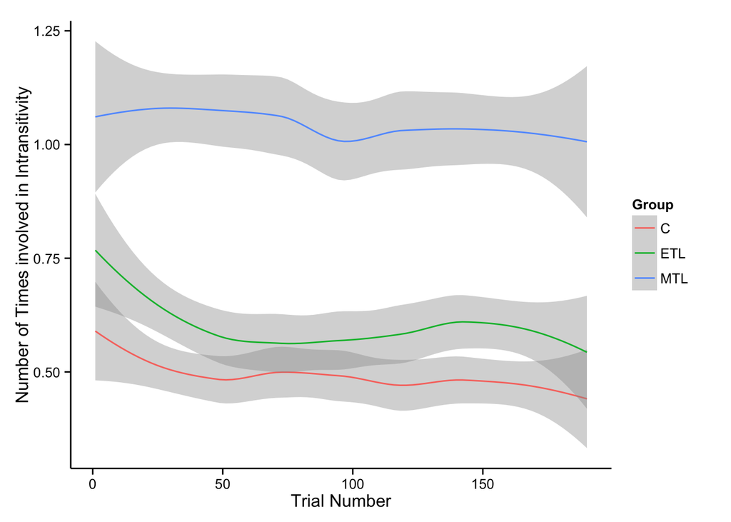

```r
#Plot S1
ggplot(data=choice2.trial.data, aes(x = Trialnumber, y = IntransTripleCounted, group = Group, col = Group))+
  geom_smooth(method = "loess") +
  theme_classic()+
  ylab("Number of Times involved in Intransitivity") +
  xlab("Trial Number")
```

### Intransitivities and response times

Wait for mediation.

```r
choice2.trial.data$RT.quad[choice2.trial.data$RT>0] <- choice2.trial.data$RT^2[choice2.trial.data$RT>0]

choice2.trial.data$RT.c <- choice2.trial.data$RT - mean(choice2.trial.data$RT[choice2.trial.data$RT>0])

choice2.trial.data$RT.quad.c <- choice2.trial.data$RT.quad - mean(choice2.trial.data$RT.quad)

a4 <- lmerTest::lmer(IntransTripleCounted ~ RT.c + RT.quad.c + Group + RT.c:Group + (1 | f.id), data=choice2.trial.data)
summary(a4.lmerTest)

a2 <- lmerTest::lmer(IntransTripleCounted ~ Group + (1 | f.id), data=choice2.trial.data)
summary(a2)

anova(a4, a2)

# Don't think this plot is good for our claim on speed-accuracy trade-off
ggplot(data = choice2.trial.data[choice2.trial.data$RT>500 & choice2.trial.data$RT<5001,], aes(x=RT, y = IntransTripleCounted, group = Group, col = Group))+
  theme_classic()+
  geom_smooth(method = "loess")+
  ylab("Number of Times Involved in Intransitivitiy")+
  xlim(0,5000)

#Mediation?
med.lmer.c <-  lmerTest::lmer(IntransTripleCounted ~ (1|f.id) + Group +Trialnumber, data=choice2.trial.data[choice2.trial.data$RT>0,])
summary(med.lmer.c)

med.lmer.a <- lmerTest::lmer(RT ~ (1|f.id) + Group + Trialnumber, data=choice2.trial.data[choice2.trial.data$RT>0,])
summary(med.lmer.a)

med.lmer.b <- lmerTest::lmer(IntransTripleCounted ~ (1|f.id) + Group + RT + Trialnumber, data=choice2.trial.data[choice2.trial.data$RT>0,])
summary(med.lmer.b)
```

### Data cleaning

```r
names(both.Intransitive)
```

```
##  [1] "f.id"                       "Group"
##  [3] "Intrans"                    "TimeOutTriplets"
##  [5] "MisPressTriplets"           "ErrorTriplets"
##  [7] "MisPressIntransTriplets"    "ErrorIntransTriplets"
##  [9] "TimeOutTrials"              "MisPressTrials"
## [11] "EitherErrorTrials"          "PercentTimeOutTrials"
## [13] "PercentMisPressTrials"      "PercentEitherErrorTrials"
## [15] "PercentTimeOutTriplets"     "PercentMisPressTriplets"
## [17] "PercentEitherErrorTriplets" "PIntrError"
## [19] "CleanTriplets"              "CleanIntr"
## [21] "CleanPercentIntr"           "Task"
```

```r
summary(both.Intransitive$CleanTriplets[both.Intransitive$Task == "choice"])/1140*100
```

```
##    Min. 1st Qu.  Median    Mean 3rd Qu.    Max.
##   28.60   96.49   98.25   95.61  100.00  100.00
```